# ExercisePart2Sousa

Thibault Schowing

12/03/2020

## Exercise 2

```r
# install scrm package
#install.packages("diagram")
#install.packages("plotrix")

# Load the package
library("diagram")
library("plotrix")
```

# Objectives of this practical session

1. What is the SFS?
- Build the derived SFS from genotypic data
- Multi-dimensional SFS (2D-SFS)
2. Does the SFS contain information about demography?
- Infer parameters under simple models with fastsimcoal2 with simulated data 3.Application to real data from human populations (OPTIONAL)
- Apply fastsimcoal2 for a model with two populations
- Compare results with and without gene flow

# 1. What is the site frequency spectrum (SFS)?

The SFS (also called Allele frequency spectrum - AFS) is a summary of genome-wide data that describes the number of single nucleotide polymorphisms (SNPs) with a given derived allele frequency in our sample.

## 1.1. Multi-dimensional SFS (2D-SFS)

The SFS can be extended to any number of populations. For instance, if we had sampled data from two populations, the 2D-SFS corresponds to a matrix where the entry (i,j) corresponds to the count of genomic sites (SNPs) with a derived allele frequency of i in population 1, and frequency j in population 2.

The 2D SFS can be seen as a matrix. Before starting answer the following questions:

- How many rows has the 2D SFS for this dataset? What determines the number of rows?

7 rows (from 0 to 6),

- How many columns has this 2D SFS for this dataset? What determines the number of columns?

5 columns (from 0 to 4)

- What is the range of possible values for each entry of the matrix?

From 0 to 12, it is the number of site with the pop1/pop2 allele frequency. (Independent from the site)

First, you need to compute the absolute allele frequency for each SNP in each population.

Second, you need to count the number of sites with a given allele frequency in each population.

| Pop2 | Pop1 |  |  |  |  |
| --- | --- | --- | --- | --- | --- |
|  | 0 | 1 | 2 | 3 | 4 |
| 0 | 2 | 1 | 0 | 0 | 0 |
| 1 | 2 | 2 | 1 | 0 | 0 |
| 2 | 1 | 2 | 0 | 0 | 0 |
| 3 | 0 | 0 | 0 | 0 | 0 |
| 4 | 0 | 1 | 0 | 0 | 0 |
| 5 | 0 | 0 | 0 | 0 | 0 |
| 6 | 0 | 0 | 0 | 0 | 0 |

## Example of a 2D-SFS

The *not* following matrix contains the 2D-SFS of 50,000 simulated sites from two populations, with a sample size of 2 diploids for pop1 and 3 diploids for pop2. Hence, we have 5 rows and 7 columns. Each entry (i,j) contains the number of SNPs with a derived allele frequency of i in pop1, and j in pop2. The sum of the entries in this matrix is the total number os sites, which in this case is 50,000.

## Exercise 1.2 (5 min)

- How many sites have 1 heterozygote individual in pop1 and 1 heterozygote individual in pop2?

Take the intersection of row[1] and col[1] -> 2005

- How many sites have a derived allele frequency of 4 in pop1 and a derived allele frequency of 4 in pop2?

Intersection of row[4] and col[4] -> 407

# 2. Does the SFS contain information about demography?

## 2.1. Infer parameters under simple models with fastsimcoal2 with simulated data

We will analyse data simulated according to the following model. (not here)

```r
# read the observed SFS
# 2D from two populations with different Ne that diverged some time ago
pop2d <- read.table("./FscInputFiles/2PopDiv20Mb_jointDAFpop1_0.obs", skip=1, stringsAsFactors = F, header=T, row.names = 1)
```

2.1.2. Input files: DEFINITION OF MODELS The model is defined in a TPL file, and the search range for the parameters are defined in the EST file.

2.1.3 Settings to run fastsimcoal2 To run fastsimcoal2 we need to specify: - the number of coalescent simulations to approximate the expected SFS (-n and -N option). This should be larger than 100,000. - the number of optimization cycles (-l and -L option). This should be at least 20, but values between 50 and 100 are recommended.

2.2. Run fastsimcoal2 from R The following scripts will run 1 fastsimcoal2 optimization, starting from a random initial starting value. When dealing with real data one needs to repeat at least 20-100 runs (i.e. runs with different initial starting values), selecting the run that maximizes the likelihood.

```r
# load functions to run fastsimcoal2 and to process the output
source("utilFscFunctions.r")
source("ParFileInterpreter-VS1.r")

# create a list that saves all the required settings to run fastsimcoal2
settings <- list()
# path to fastsicoal2 executable file
settings$pathToFsc <- "./fastsimcoal2/fsc_linux64/"
# path to input files (working directory)
settings$pathTo_InputFile <- "./FscInputFiles/"
# path to TPL and EST file (tags)
settings$TPL_EST_file_tag <- "2PopDiv20Mb"
# number of coalescent simulations
settings$n_coalsims <- 100000
# number of optimization cycles
settings$n_cycles <- 20

# run fastsimcoal2
#run_fsc2(settings)

# get the command line to run fastsimcoal2
cmd <- get_fsc2_commandline(settings)
cmd
```

```
## [1] "./fsc26  -t 2PopDiv20Mb.tpl -e 2PopDiv20Mb.est -L 20 -n 100000 -d -M -q -C1 -c2 -B2;"
```

```r
# STOP HERE!!!!
# You need to run this in a command line (cmd in Windows) or in a Unix terminal in Linux or Mac.
```

```
C:\Users\...\FscInputFiles>fsc26  -t 2PopDiv20Mb.tpl -e 2PopDiv20Mb.est -L 20 -n 100000 -d -M -q -C1 -c2 -B2;
fastsimcoal was invoked with the following command line arguments:
fsc26 -t 2PopDiv20Mb.tpl -e 2PopDiv20Mb.est -L 20 -n 100000 -d -M -q -C1 -c2 -B2;
Invalid number of batches (2;), setting it to default value of 12)

Random generator seed : 915281

No population growth detected in input file

Estimating model parameters using 12 batches and 2 threads

Estimation of parameters by conditional maximization via Brent algorithm (initial lhood = -1.0548e+006)

Iter 1  Curr best params:       1792    1348    16919   235     lhood=-138763

Iter 2  Curr best params:       2425    950     11579   157     lhood=-137566

Iter 3  Curr best params:       4464    886     11361   170     lhood=-137523

Iter 4  Curr best params:       6552    877     11087   179     lhood=-137517

Iter 5  Curr best params:       6552    995     11087   200     lhood=-137508

Iter 6  Curr best params:       5597    1143    11208   234     lhood=-137503

Iter 7  Curr best params:       6881    1276    11095   256     lhood=-137491

Iter 8  Curr best params:       8059    1518    10984   324     lhood=-137473

Iter 9  Curr best params:       12428   1845    10874   401     lhood=-137450

Iter 10 Curr best params:       12658   2181    10736   483     lhood=-137432

Iter 11 Curr best params:       17553   2555    10623   557     lhood=-137414

Iter 12 Curr best params:       16523   2925    10623   619     lhood=-137399

Iter 13 Curr best params:       14254   3295    10516   679     lhood=-137388

Iter 14 Curr best params:       16908   3604    10239   791     lhood=-137377

Iter 15 Curr best params:       19038   4166    10136   857     lhood=-137366

Iter 16 Curr best params:       19038   4477    10034   903     lhood=-137364

Iter 17 Curr best params:       19732   4477    10034   903     lhood=-137363

Iter 18 Curr best params:       19138   4669    10034   916     lhood=-137362

Iter 19 Curr best params:       18740   4823    10034   957     lhood=-137362

Iter 20 Curr best params:       19495   4961    9933    986     lhood=-137361

Program total execution time: 141.687 seconds
```

```r
# Once you run it, you can read the results.
# read the file with the maximum likelihood estimates
maxlhoodEstimates <- read.table(paste(settings$pathTo_InputFile, "/",
                                      settings$TPL_EST_file_tag, "/",
                                      settings$TPL_EST_file_tag, ".bestlhoods",
                                      sep=""), header=T)
# look at the parameter estimates
maxlhoodEstimates
```

```
##   NPOP1 NPOP2 NANC TDIV MaxEstLhood MaxObsLhood
## 1 19495  4961 9933  986   -137360.6   -137353.9
```

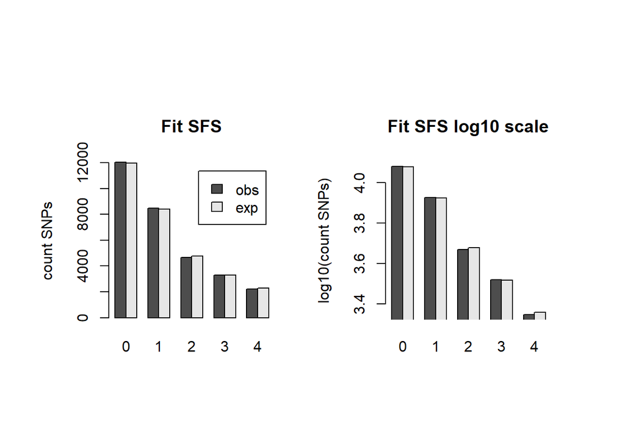

```r
# Read the observed SFS
obsfileend <- "_jointDAFpop1_0"
pop2d <- read.table(paste(settings$pathTo_InputFile,
                    settings$TPL_EST_file_tag, obsfileend, ".obs",
                    sep=""), skip=1, stringsAsFactors = F, header=T)
# Read the expected SFS
expectedSFS <- read.table(paste(settings$pathTo_InputFile,
                    settings$TPL_EST_file_tag, "/",
                    settings$TPL_EST_file_tag, obsfileend, ".txt",
                    sep=""), header=T)

# discard the monomorphic sites from the observed SFS
pol_obs_2d <- as.matrix(pop2d)
# observed SFS just with SNPs (polymorphic sites)
pol_obs_2d[c(1,1)] <- 0
# get the marginal 1d sfs for pop 1
marginal1d_sfs <- rowSums(pol_obs_2d)
exp.marginal1d_sfs <- rowSums(expectedSFS)
# Plot the observed vs expected SFS
plot_fitSFS_1d(marginal1d_sfs, exp.marginal1d_sfs, c(1,max(marginal1d_sfs)*1.1), "pop1")
```

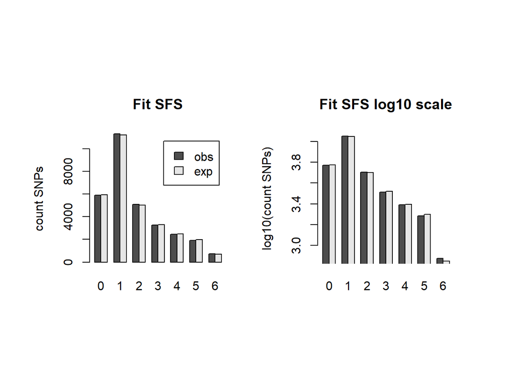

```r
# get the marginal 1d sfs for pop 2
marginal1d_sfs <- colSums(pol_obs_2d)
exp.marginal1d_sfs <- colSums(expectedSFS)
# Plot the observed vs expected SFS
plot_fitSFS_1d(marginal1d_sfs, exp.marginal1d_sfs, c(1,max(marginal1d_sfs)*1.1), "pop2")
```

RESULTS of 1 run What is the MaxObsLhood and the MaxEstLhood?

MaxObsLhood: is the maximum possible value for the likelihood if there was a perfect fit of the expected to the observed SFS, i.e. if the expected SFS was the relative observed SFS.

MaxEstLhood: is the maximum likelihood estimated according to the model parameters.

The better the fit, the smaller the difference between MaxObsLhood and MaxEstLhood

DISCUSSION - Is the method able to infer the correct parameters?

- Does the expected SFS fit the observed SFS?